# PINN Solver

## Overview

The PINN (Physics-Informed Neural Network) solver provides an alternative to the finite-difference level set method. Instead of discretizing the PDE on a grid, a neural network $\varphi_\theta(x, y, t)$ is trained to satisfy the Hamilton-Jacobi fire spread equation:

$$\frac{\partial \varphi}{\partial t} + F(x,y,t)\lvert\nabla \varphi\rvert = 0$$

where $F$ is the spread rate from a `RothermelModel` or any callable $(t, x, y) \to R$.

### Hard Initial Condition Constraint

The PINN uses a **solution decomposition** that exactly satisfies the initial condition:

$$\tilde\varphi(x,y,t) = \frac{\text{IC}(x,y)}{L} + \tau(t) \cdot \text{NN}_\theta(x_n, y_n, t_n)$$

where $\tau(t) = (t - t_{\min}) / (t_{\max} - t_{\min})$ is zero at $t = t_{\min}$, ensuring $\tilde\varphi(x,y,t_{\min}) = \text{IC}(x,y)/L$ exactly. This eliminates the need for an IC loss term and lets all training focus on learning the PDE dynamics.

### Advantages

- **Mesh-free**: Evaluate $\varphi$ at any continuous $(x, y, t)$ – no grid interpolation needed
- **Continuous in time**: Query the fire state at any $t$ without stepping through intermediate time steps
- **Exact initial condition**: Hard constraint guarantees perfect IC fit
- **Data assimilation ready**: Optional observation loss term for incorporating satellite/sensor data

### Requirements

The PINN solver is a **package extension** – it only loads when the ML dependencies are available:

```julia
using Wildfires
using Lux, ComponentArrays, ForwardDiff, Zygote, Optimization, OptimizationOptimisers
```

## Quick Start

```julia
# Set up a fire scenario
grid = LevelSetGrid(20, 20, dx=50.0)
ignite!(grid, 500.0, 500.0, 80.0)

# Simple constant spread model for fast training
const_spread = (t, x, y) -> 5.0

# Configure PINN
config = PINNConfig(
    hidden_dims = [32, 32],
    n_interior = 500,
    n_boundary = 100,
    max_epochs = 3000,
    learning_rate = 1e-3,
    resample_every = 500,
)

# Train
sol = train_pinn(grid, const_spread, (0.0, 10.0);
                 config=config, rng=MersenneTwister(123), verbose=false)

sol
```

```
PINNSolution{Lux}(epochs=3001, final_loss=0.0001157)
```

### Training Loss

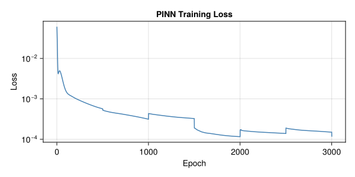

```julia
fig = Figure(size=(600, 300))
ax = Axis(fig[1, 1], xlabel="Epoch", ylabel="Loss", yscale=log10,
    title="PINN Training Loss")
lines!(ax, sol.loss_history, color=:steelblue)
fig
```

## PINN Predictions

The `PINNSolution` is callable – query $\varphi$ at any point:

```julia
# Single point evaluation
sol(5.0, 500.0, 500.0)
```

```
-48.06566849824875
```

Evaluate on the full grid at a specific time with `predict_on_grid`:

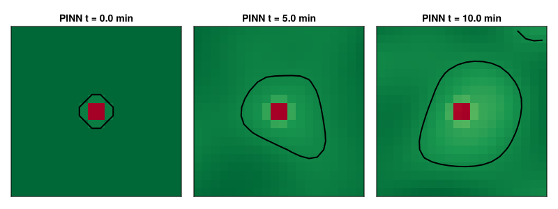

```julia
fig = Figure(size=(800, 300))
for (col, t) in enumerate([0.0, 5.0, 10.0])
    φ = predict_on_grid(sol, grid, t)
    ax = Axis(fig[1, col], title="PINN t = $t min", aspect=DataAspect())
    heatmap!(ax, collect(xcoords(grid)), collect(ycoords(grid)), φ, colormap=:RdYlGn)
    contour!(ax, collect(xcoords(grid)), collect(ycoords(grid)), φ, levels=[0.0],
        color=:black, linewidth=2)
    hidedecorations!(ax)
end
fig
```

Or update a `LevelSetGrid` in place with `predict_on_grid!`:

```julia
grid_pinn = LevelSetGrid(20, 20, dx=50.0)
predict_on_grid!(grid_pinn, sol, 5.0)
grid_pinn
```

```
LevelSetGrid{Float64} 20×20 (t=5.0, burned=68/400)
```

## Comparison with Finite Differences

The PINN solution can be compared against the standard finite-difference solver. Note that PINNs are an approximate method – accuracy improves with larger networks, more collocation points, and longer training:

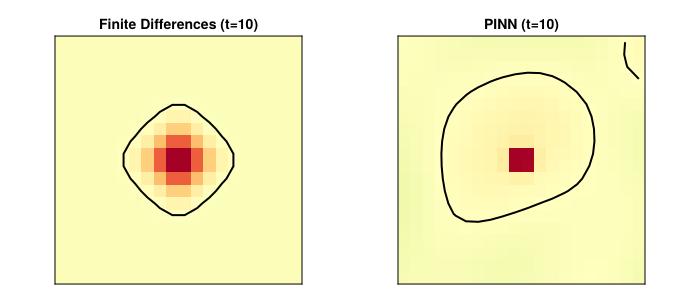

```julia
# Finite-difference reference with constant F = 5.0 m/min
grid_fd = LevelSetGrid(20, 20, dx=50.0)
ignite!(grid_fd, 500.0, 500.0, 80.0)
F = fill(5.0, size(grid_fd))
for _ in 1:20
    advance!(grid_fd, F, 0.5)
end

# PINN prediction at the same time
grid_pinn = LevelSetGrid(20, 20, dx=50.0)
predict_on_grid!(grid_pinn, sol, 10.0)

fig = Figure(size=(700, 300))

ax1 = Axis(fig[1, 1], title="Finite Differences (t=10)", aspect=DataAspect())
fireplot!(ax1, grid_fd)
hidedecorations!(ax1)

ax2 = Axis(fig[1, 2], title="PINN (t=10)", aspect=DataAspect())
fireplot!(ax2, grid_pinn)
hidedecorations!(ax2)

fig
```

## Configuration

`PINNConfig` controls all training hyperparameters:

| Parameter | Default | Description |
| --- | --- | --- |
| `hidden_dims` | `[64, 64, 64]` | Hidden layer sizes |
| `activation` | `:tanh` | Activation function |
| `n_interior` | `5000` | PDE collocation points |
| `n_boundary` | `500` | Boundary condition points |
| `lambda_pde` | `1.0` | PDE loss weight |
| `lambda_bc` | `1.0` | BC loss weight |
| `lambda_data` | `1.0` | Data loss weight |
| `learning_rate` | `1e-3` | Adam learning rate |
| `max_epochs` | `10000` | Maximum training epochs |
| `resample_every` | `500` | Resample collocation points every N epochs |
| `lbfgs_epochs` | `0` | L-BFGS refinement iterations after Adam (0 = disabled) |
| `importance_sampling` | `false` | Concentrate collocation points near fire front |
| `float32` | `false` | Use Float32 for NN weights (halves memory) |

### Tuning Hyperparameters

**Network size (`hidden_dims`)**: Start with `[32, 32]` for quick experiments and scale up to `[64, 64, 64]` or larger for production. Wider/deeper networks fit complex fire fronts better but train slower. If the loss plateaus early, try increasing network capacity.

**Collocation points (`n_interior`, `n_boundary`)**: More points improve accuracy but slow each epoch. A good rule of thumb: use at least 10x the number of grid cells for `n_interior`. `n_boundary` can be ~10% of `n_interior`.

**Learning rate**: The default `1e-3` works well with Adam for most cases. If the loss oscillates, reduce to `1e-4`. If training is very slow, try `3e-3` briefly.

**Loss weights (`lambda_pde`, `lambda_bc`, `lambda_data`)**: The defaults of `1.0` for all terms are a reasonable starting point. If the fire front bleeds through boundaries, increase `lambda_bc` (e.g., `10.0`). When using observations, increase `lambda_data` (e.g., `5.0`–`10.0`) to tighten the fit to observed perimeters.

**Resampling (`resample_every`)**: Periodically resampling collocation points prevents overfitting to a fixed set of training locations. The default of `500` epochs works well; lower values (e.g., `100`) can help if the loss stagnates.

**L-BFGS refinement (`lbfgs_epochs`)**: After Adam converges to the right neighborhood, L-BFGS can polish the solution with second-order curvature information. Typical values are 100–500 iterations. Requires passing the optimizer explicitly:

```julia
using OptimizationOptimJL

config = PINNConfig(max_epochs=5000, lbfgs_epochs=200)
sol = train_pinn(grid, model, tspan;
                 config=config, lbfgs_optimizer=OptimizationOptimJL.LBFGS())
```

**Importance sampling (`importance_sampling`)**: When enabled, half the collocation points are sampled uniformly and half are concentrated near the initial fire front (where $|\varphi|$ is small). This focuses training capacity on the region that matters most. Enable it when the loss plateaus or the fire front is poorly resolved relative to the domain size.

**Float32 weights (`float32`)**: Halves NN memory and can speed up forward/backward passes. Collocation points remain Float64 for spatial accuracy. Try this when memory is tight or training is slow. May reduce precision slightly.

## Loss Function

The total loss is a weighted sum of three terms:

$$\mathcal{L} = \lambda_{\text{pde}} \mathcal{L}_{\text{pde}} + \lambda_{\text{bc}} \mathcal{L}_{\text{bc}} + \lambda_{\text{data}} \mathcal{L}_{\text{data}}$$

- **PDE residual** ($\mathcal{L}_{\text{pde}}$): Enforces the Hamilton-Jacobi equation at random interior points
- **Boundary condition** ($\mathcal{L}_{\text{bc}}$): Penalizes burned regions ($\varphi < 0$) at the domain boundary
- **Data loss** ($\mathcal{L}_{\text{data}}$): Optional – fits to observed fire perimeter data

The initial condition is enforced exactly through the hard constraint decomposition (no IC loss term needed).

## Data Assimilation

Pass observations as a tuple of vectors `(t, x, y, phi)` to incorporate fire perimeter data:

```julia
# Example: observations at t=10 along a known fire boundary
obs_t = fill(10.0, 50)
obs_x = rand(400.0:800.0, 50)
obs_y = rand(400.0:800.0, 50)
obs_phi = zeros(50)  # on the fire front (phi = 0)

sol = train_pinn(grid, model, (0.0, 20.0);
                 observations=(obs_t, obs_x, obs_y, obs_phi))
```

**Observation format details:**

- **`t`**: Time in minutes (same units as the simulation time span)
- **`x`, `y`**: Spatial coordinates in meters (same coordinate system as the `LevelSetGrid`)
- **`phi`**: Target level set value. Use `0.0` for points on the fire front, negative for burned, positive for unburned.
- Observations at **multiple times** are supported — just vary the `t` values.
- As few as 20–50 well-placed perimeter points can significantly improve the solution. Points along the fire front (`phi = 0`) are most informative.

## References

- Raissi, M., Perdikaris, P., & Karniadakis, G. E. (2019). *Physics-informed neural networks: A deep learning framework for solving forward and inverse problems involving nonlinear partial differential equations.* Journal of Computational Physics, 378, 686-707.
- Osher, S. & Sethian, J.A. (1988). *Fronts propagating with curvature-dependent speed.* J. Computational Physics, 79(1), 12-49.